# TFM

```python
import subprocess
import sys
import os
import re
import atexit
import numpy as np
import seaborn as sns
import matplotlib.pyplot as plt
import pandas as pd
import ipywidgets as widgets
import datetime as dt
from sklearn.preprocessing import OneHotEncoder

# Librería para evitar mensajes de warning al ejecutar código Python
#import warnings
#warnings.simplefilter(action='ignore', category=FutureWarning)
#warnings.simplefilter(action='ignore')

# Librería para cronometrar tiempos de ejecución
#import time
#start_time = time.time()

# Definición de constantes
FIRST_DATE = dt.datetime(2012,12,1)
LAST_DATE = dt.datetime(2015,12,31)
```

## Carga de datos

```python
# Diccionario con features y sus tipos
dtype = {'DeviceID':str, 'Fault_Code_Type_1':str, 'Fault_Code_Type_2':str, 'Fault_Code_Type_3':str, 'Fault_Code_Type_4':str}

# Carga del dataset teniendo en cuenta el diccionario definido y el formato de la feature de tipo fecha
df = pd.read_csv('sampledata.csv', sep=',', dtype=dtype, parse_dates=['Date'], infer_datetime_format=True)
```

## Preprocesamiento de datos

```python
# Verificación del dataframe: dimesiones y tipo de sus features
print('Dimensiones del dataframe: {}'.format(df.shape))
print('\nTipo de las features:\n{}'.format(df.dtypes))
```

```
Dimensiones del dataframe: (2085102, 172)

Tipo de las features:
DeviceID                     object
Date                 datetime64[ns]
Categorical_1                 int64
Categorical_2                 int64
Categorical_3                 int64
Categorical_4                 int64
Problem_Type_1                int64
Usage_Count_1                 int64
Usage_Count_2                 int64
Problem_Type_2                int64
Problem_Type_3                int64
Problem_Type_4                int64
Warning_1.2                   int64
Warning_1.3                   int64
Warning_1.4                   int64
Warning_1.5                   int64
Warning_1.6                   int64
Warning_1.7                   int64
Warning_1.8                   int64
Warning_1.9                   int64
Warning_1.10                  int64
Warning_1.11                  int64
Warning_1.12                  int64
Warning_1.13                  int64
Warning_1.14                  int64
Warning_1.15                  int64
Warning_1.16                  int64
Warning_1.17                  int64
Warning_1.18                  int64
Warning_1.19                  int64
                          ...
Warning_2.91                  int64
Warning_2.92                  int64
Warning_2.93                  int64
Warning_2.94                  int64
Warning_2.95                  int64
Warning_2.96                  int64
```

[output cut: 10 more lines]

```
Warning_2.107                 int64
Error_Count_1                 int64
Error_Count_2                 int64
Error_Count_3                 int64
Error_Count_4                 int64
Error_Count_5                 int64
Error_Count_6                 int64
Error_Count_7                 int64
Error_Count_8                 int64
Fault_Code_Type_1            object
Fault_Code_Type_2            object
Fault_Code_Type_3            object
Fault_Code_Type_4            object
ProblemReported               int64
Length: 172, dtype: object
```

#### Definición de las features:

- *DeviceID*: identificador de la máquina.
- *Date*: fecha del registro (fila).
- *Categorical_X*: variables categóricas de la máquina (x4).
- *Problem_Type_X*: número total de problemas de un tipo reportados por la máquina durante un día (x4).
- *Usage_Count_X*: número total de veces que la máquina ha sido usada en cada modo de funcionamiento (x2).
- *Warning_X*: número total de avisos reportados por la máquina durante un día (x147).
- *Error_Count_X*: número total de errores de un tipo reportados por la máquina durante un día (x8).
- *Fault_Code_Type_X*: tipo de código de fallo reportado por la máquina durante un día (x4).
- *ProblemReported*: feature objetivo (a predecir), que indica si la máquina tuvo un problema durante un día.

```python
# Borrado de filas duplicadas cuyos valores coincidan en 'DeviceID' y 'Date'
df = df.drop_duplicates(['DeviceID', 'Date'])

# Borrado de filas en las que no exista valor en 'DeviceID' o 'Date'
df = df.dropna(how='any', subset=['DeviceID', 'Date'])

# Instrucción para hacer que la dupla 'DeviceID' y 'Date' sean los índices del dataframe
#df = df.set_index(['DeviceID', 'Date'])

# Creación de las features 'Day', 'Month' y 'Year', extraidas de la feature 'Date'
df['Day'] = df['Date'].dt.day
df['Month'] = df['Date'].dt.month
df['Year'] = df['Date'].dt.year
```

```python
# Definición de grupos de features: date, categorical, numeric
datetime_features = ['Date', 'Day', 'Month', 'Year']
categorical_features = ['DeviceID', 'Categorical_1', 'Categorical_2', 'Categorical_3', 'Categorical_4',
                        'Fault_Code_Type_1', 'Fault_Code_Type_2', 'Fault_Code_Type_3', 'Fault_Code_Type_4']
warning_type1_features = [feature for feature in df.columns if feature.startswith('Warning_1')]
warning_type2_features = [feature for feature in df.columns if feature.startswith('Warning_2')]
warning_features = warning_type1_features + warning_type2_features
numeric_features = list(set(df.columns) - set(datetime_features) - set(categorical_features))

# Tratamiento de datos no registrados: valor 0 para features numéricas
values = dict(zip(numeric_features, np.zeros(len(numeric_features))))
df = df.fillna(value=values)

# Tratamiento de datos no registrados: valor 'Unknown' para features categóricas
values = dict(zip(categorical_features, ['Unknown' for k in range(len(categorical_features))]))
df = df.fillna(value=values)

# Visualización de los 5 primeros registros del dataframe
df.head()
```

|  | DeviceID | Date | Categorical_1 | Categorical_2 | Categorical_3 | Categorical_4 | Problem_Type_1 | Usage_Count_1 | Usage_Count_2 | Problem_Type_2 | ... | Error_Count_7 | Error_Count_8 | Fault_Code_Type_1 | Fault_Code_Type_2 | Fault_Code_Type_3 | Fault_Code_Type_4 | ProblemReported | Day | Month | Year |
| --- | --- | --- | --- | --- | --- | --- | --- | --- | --- | --- | --- | --- | --- | --- | --- | --- | --- | --- | --- | --- | --- |
| 0 | N0001 | 2012-12-08 | 8 | 1500 | 100 | 7106 | 0 | 0 | 0 | 0 | ... | 0 | 0 | Unknown | Unknown | Unknown | Unknown | 0 | 8 | 12 | 2012 |
| 1 | N0001 | 2012-12-09 | 8 | 1500 | 100 | 7106 | 0 | 0 | 0 | 0 | ... | 0 | 0 | Unknown | Unknown | Unknown | Unknown | 0 | 9 | 12 | 2012 |
| 2 | N0001 | 2012-12-10 | 8 | 1500 | 100 | 7106 | 0 | 0 | 0 | 0 | ... | 0 | 0 | Unknown | Unknown | Unknown | Unknown | 0 | 10 | 12 | 2012 |
| 3 | N0001 | 2012-12-11 | 8 | 1500 | 100 | 7106 | 0 | 0 | 0 | 0 | ... | 0 | 0 | Unknown | Unknown | Unknown | Unknown | 0 | 11 | 12 | 2012 |
| 4 | N0001 | 2012-12-12 | 8 | 1500 | 100 | 7106 | 0 | 0 | 0 | 0 | ... | 0 | 0 | Unknown | Unknown | Unknown | Unknown | 0 | 12 | 12 | 2012 |

5 rows × 175 columns

```python
# Detección de valores negativos en features que hacen de contadores
df[numeric_features].describe()
```

|  | Warning_1.33 | Warning_2.63 | Warning_2.81 | Warning_2.56 | Warning_2.3 | Warning_2.93 | Warning_2.57 | Warning_2.64 | Warning_2.29 | Warning_1.12 | ... | Warning_2.49 | ProblemReported | Warning_2.30 | Warning_2.52 | Warning_2.20 | Warning_2.67 | Warning_2.78 | Error_Count_4 | Usage_Count_1 | Warning_2.66 |
| --- | --- | --- | --- | --- | --- | --- | --- | --- | --- | --- | --- | --- | --- | --- | --- | --- | --- | --- | --- | --- | --- |
| count | 2085102.0 | 2.085102e+06 | 2.085102e+06 | 2085102.0 | 2085102.0 | 2.085102e+06 | 2.085102e+06 | 2.085102e+06 | 2085102.0 | 2.085102e+06 | ... | 2.085102e+06 | 2.085102e+06 | 2.085102e+06 | 2.085102e+06 | 2085102.0 | 2.085102e+06 | 2.085102e+06 | 2.085102e+06 | 2.085102e+06 | 2.085102e+06 |
| mean | -10.0 | -9.849034e+00 | -9.994534e+00 | -10.0 | -10.0 | -9.719726e+00 | -9.999995e+00 | -9.998427e+00 | -10.0 | -9.990561e+00 | ... | -9.967883e+00 | 1.910698e-03 | -9.999953e+00 | -9.926698e+00 | -10.0 | -9.774329e+00 | -9.949070e+00 | 4.316336e-04 | 3.816079e+02 | -9.994782e+00 |
| std | 0.0 | 1.544099e+00 | 4.084725e-01 | 0.0 | 0.0 | 2.302713e+00 | 7.617791e-03 | 1.345550e-01 | 0.0 | 3.359755e-01 | ... | 1.063396e+00 | 4.366976e-02 | 2.285333e-02 | 2.507259e+00 | 0.0 | 1.661925e+00 | 8.892755e-01 | 2.077131e-02 | 5.104107e+02 | 2.481925e-01 |
| min | -10.0 | -1.000000e+01 | -1.000000e+01 | -10.0 | -10.0 | -1.000000e+01 | -1.000000e+01 | -1.000000e+01 | -10.0 | -1.000000e+01 | ... | -1.000000e+01 | 0.000000e+00 | -1.000000e+01 | -1.000000e+01 | -10.0 | -1.000000e+01 | -1.000000e+01 | 0.000000e+00 | -3.266100e+04 | -1.000000e+01 |
| 25% | -10.0 | -1.000000e+01 | -1.000000e+01 | -10.0 | -10.0 | -1.000000e+01 | -1.000000e+01 | -1.000000e+01 | -10.0 | -1.000000e+01 | ... | -1.000000e+01 | 0.000000e+00 | -1.000000e+01 | -1.000000e+01 | -10.0 | -1.000000e+01 | -1.000000e+01 | 0.000000e+00 | 0.000000e+00 | -1.000000e+01 |
| 50% | -10.0 | -1.000000e+01 | -1.000000e+01 | -10.0 | -10.0 | -1.000000e+01 | -1.000000e+01 | -1.000000e+01 | -10.0 | -1.000000e+01 | ... | -1.000000e+01 | 0.000000e+00 | -1.000000e+01 | -1.000000e+01 | -10.0 | -1.000000e+01 | -1.000000e+01 | 0.000000e+00 | 6.800000e+01 | -1.000000e+01 |
| 75% | -10.0 | -1.000000e+01 | -1.000000e+01 | -10.0 | -10.0 | -1.000000e+01 | -1.000000e+01 | -1.000000e+01 | -10.0 | -1.000000e+01 | ... | -1.000000e+01 | 0.000000e+00 | -1.000000e+01 | -1.000000e+01 | -10.0 | -1.000000e+01 | -1.000000e+01 | 0.000000e+00 | 6.980000e+02 | -1.000000e+01 |
| max | -10.0 | 4.790000e+02 | 2.580000e+02 | -10.0 | -10.0 | 4.050000e+02 | 1.000000e+00 | 7.000000e+00 | -10.0 | 1.800000e+01 | ... | 2.800000e+02 | 1.000000e+00 | 1.000000e+00 | 2.760000e+02 | -10.0 | 2.570000e+02 | 2.760000e+02 | 1.000000e+00 | 3.256500e+04 | 2.800000e+01 |

8 rows × 162 columns

```python
# Convertir valores negativos de todas las features numéricas (que hacen de contadores) en cero
for feature in numeric_features:
    df.loc[(df[feature] < 0), feature] = 0

# Comprobación
df[numeric_features].describe()
```

|  | Warning_1.33 | Warning_2.63 | Warning_2.81 | Warning_2.56 | Warning_2.3 | Warning_2.93 | Warning_2.57 | Warning_2.64 | Warning_2.29 | Warning_1.12 | ... | Warning_2.49 | ProblemReported | Warning_2.30 | Warning_2.52 | Warning_2.20 | Warning_2.67 | Warning_2.78 | Error_Count_4 | Usage_Count_1 | Warning_2.66 |
| --- | --- | --- | --- | --- | --- | --- | --- | --- | --- | --- | --- | --- | --- | --- | --- | --- | --- | --- | --- | --- | --- |
| count | 2085102.0 | 2.085102e+06 | 2.085102e+06 | 2085102.0 | 2085102.0 | 2.085102e+06 | 2.085102e+06 | 2.085102e+06 | 2085102.0 | 2.085102e+06 | ... | 2.085102e+06 | 2.085102e+06 | 2.085102e+06 | 2.085102e+06 | 2085102.0 | 2.085102e+06 | 2.085102e+06 | 2.085102e+06 | 2.085102e+06 | 2.085102e+06 |
| mean | 0.0 | 2.959088e-02 | 1.384585e-03 | 0.0 | 0.0 | 4.945993e-02 | 4.795928e-07 | 1.966331e-04 | 0.0 | 1.362523e-03 | ... | 1.617043e-02 | 1.910698e-03 | 4.316336e-06 | 4.252694e-02 | 0.0 | 3.515799e-02 | 9.685378e-03 | 4.316336e-04 | 3.816666e+02 | 7.050015e-04 |
| std | 0.0 | 7.749748e-01 | 3.136442e-01 | 0.0 | 0.0 | 1.442656e+00 | 6.925264e-04 | 2.026063e-02 | 0.0 | 7.037627e-02 | ... | 8.054235e-01 | 4.366976e-02 | 2.077575e-03 | 2.265307e+00 | 0.0 | 4.509899e-01 | 4.326121e-01 | 2.077131e-02 | 5.093598e+02 | 4.895415e-02 |
| min | 0.0 | 0.000000e+00 | 0.000000e+00 | 0.0 | 0.0 | 0.000000e+00 | 0.000000e+00 | 0.000000e+00 | 0.0 | 0.000000e+00 | ... | 0.000000e+00 | 0.000000e+00 | 0.000000e+00 | 0.000000e+00 | 0.0 | 0.000000e+00 | 0.000000e+00 | 0.000000e+00 | 0.000000e+00 | 0.000000e+00 |
| 25% | 0.0 | 0.000000e+00 | 0.000000e+00 | 0.0 | 0.0 | 0.000000e+00 | 0.000000e+00 | 0.000000e+00 | 0.0 | 0.000000e+00 | ... | 0.000000e+00 | 0.000000e+00 | 0.000000e+00 | 0.000000e+00 | 0.0 | 0.000000e+00 | 0.000000e+00 | 0.000000e+00 | 0.000000e+00 | 0.000000e+00 |
| 50% | 0.0 | 0.000000e+00 | 0.000000e+00 | 0.0 | 0.0 | 0.000000e+00 | 0.000000e+00 | 0.000000e+00 | 0.0 | 0.000000e+00 | ... | 0.000000e+00 | 0.000000e+00 | 0.000000e+00 | 0.000000e+00 | 0.0 | 0.000000e+00 | 0.000000e+00 | 0.000000e+00 | 6.800000e+01 | 0.000000e+00 |
| 75% | 0.0 | 0.000000e+00 | 0.000000e+00 | 0.0 | 0.0 | 0.000000e+00 | 0.000000e+00 | 0.000000e+00 | 0.0 | 0.000000e+00 | ... | 0.000000e+00 | 0.000000e+00 | 0.000000e+00 | 0.000000e+00 | 0.0 | 0.000000e+00 | 0.000000e+00 | 0.000000e+00 | 6.980000e+02 | 0.000000e+00 |
| max | 0.0 | 4.790000e+02 | 2.580000e+02 | 0.0 | 0.0 | 4.050000e+02 | 1.000000e+00 | 7.000000e+00 | 0.0 | 1.800000e+01 | ... | 2.800000e+02 | 1.000000e+00 | 1.000000e+00 | 2.760000e+02 | 0.0 | 2.570000e+02 | 2.760000e+02 | 1.000000e+00 | 3.256500e+04 | 2.800000e+01 |

8 rows × 162 columns

## EDA

#### Selección de máquina, feature e intervalo de tiempo para graficar la tendencia:

```python
def ExploratoryDataAnalysis(df, device, feature, start_date, end_date):
    if(device != None and feature != None):
        eda = df.loc[(df['DeviceID'] == device)]

        from_date = start_date if start_date != None else FIRST_DATE
        to_date = end_date if end_date != None else LAST_DATE

        if(pd.date_range(from_date, to_date).size > 0):
            eda = eda[eda['Date'].isin(pd.date_range(from_date, to_date))]

            eda.plot(x='Date', y=feature)

def f(device, feature, start_date, end_date):
    ExploratoryDataAnalysis(df, device, feature, start_date, end_date)

deviceID_selector = widgets.Dropdown(options=df.DeviceID.unique(), value=None, description='Device ID:', disabled=False)
feature_selector = widgets.Dropdown(options=numeric_features, value='Usage_Count_1', description='Feature:', disabled=False)
start_date_selector = widgets.DatePicker(value=FIRST_DATE, description='From:', disabled=False)
end_date_selector = widgets.DatePicker(value=LAST_DATE, description='To:', disabled=False)

w = widgets.interactive(f, device=deviceID_selector, feature=feature_selector,
                        start_date=start_date_selector, end_date=end_date_selector)

left_box = widgets.VBox([w.children[0], w.children[1]])
right_box = widgets.VBox([w.children[2], w.children[3]])
controls = widgets.HBox([left_box, right_box])
output = w.children[-1]
display(widgets.VBox([controls, output]))
```

#### Selección de máquina, dos features e intervalo de tiempo para graficar un scatter plot:

```python
def ExploratoryDataAnalysis2(df, device, feature_x, feature_y, start_date, end_date):
    if(device != None and feature_x != None and feature_y != None):
        eda = df.loc[(df['DeviceID'] == device)]

        from_date = start_date if start_date != None else FIRST_DATE
        to_date = end_date if end_date != None else LAST_DATE

        if(pd.date_range(from_date, to_date).size > 0):
            eda = eda[eda['Date'].isin(pd.date_range(from_date, to_date))]

            eda.plot.scatter(x=feature_x, y=feature_y)

def f2(device, feature_x, feature_y, start_date, end_date):
    ExploratoryDataAnalysis2(df, device, feature_x, feature_y, start_date, end_date)

deviceID_selector = widgets.Dropdown(options=df.DeviceID.unique(), value=None, description='Device ID:', disabled=False)
feature_x_selector = widgets.Dropdown(options=numeric_features, value='Usage_Count_1', description='X-Feature:', disabled=False)
feature_y_selector = widgets.Dropdown(options=numeric_features, value='Usage_Count_2', description='Y-Feature:', disabled=False)
start_date_selector = widgets.DatePicker(value=FIRST_DATE, description='From:', disabled=False)
end_date_selector = widgets.DatePicker(value=LAST_DATE, description='To:', disabled=False)

w = widgets.interactive(f2, device=deviceID_selector, feature_x=feature_x_selector, feature_y=feature_y_selector,
                        start_date=start_date_selector, end_date=end_date_selector)

left_box = widgets.VBox([w.children[0]])
center_box = widgets.VBox([w.children[1], w.children[2]])
right_box = widgets.VBox([w.children[3], w.children[4]])
controls = widgets.HBox([left_box, center_box, right_box])
output = w.children[-1]
display(widgets.VBox([controls, output]))
```

#### Heatmap con el acumulado de una feature seleccionada por cada mes y año:

```python
def ExploratoryDataAnalysis3(df, feature):
    eda = pd.pivot_table(df, values=feature, index='Year', columns='Month', aggfunc=np.sum)
    plt.figure(figsize = (16,4))
    plt.title('Feature acumulada por mes y año', fontsize=20)
    sns.heatmap(eda, cmap="YlGnBu", annot=True, fmt='.0f')

def f3(feature):
    ExploratoryDataAnalysis3(df, feature)

feature_selector = widgets.Dropdown(options=numeric_features, value='ProblemReported', description='Feature:', disabled=False)

w = widgets.interactive(f3, feature=feature_selector)
display(w)
```

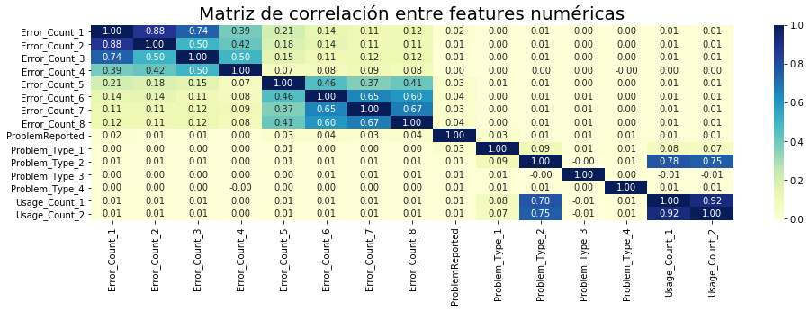

```python
# Visualización de un heatmap con la matriz de correlación entre features numéricas (sin warnings)
df_corr = df[['Error_Count_1', 'Error_Count_2', 'Error_Count_3', 'Error_Count_4',
              'Error_Count_5', 'Error_Count_6', 'Error_Count_7', 'Error_Count_8', 'ProblemReported',
            'Problem_Type_1', 'Problem_Type_2', 'Problem_Type_3', 'Problem_Type_4', 'Usage_Count_1', 'Usage_Count_2']]
corr = df_corr.corr()
plt.figure(figsize = (16,4))
plt.title('Matriz de correlación entre features numéricas', fontsize=20)
sns.heatmap(corr, xticklabels=corr.columns.values, yticklabels=corr.columns.values, cmap="YlGnBu", annot=True, fmt='.2f')
```

## Feature Engineering

#### Warnings

```python
# Creación de dos features: suma de las features de tipo Warning_1 y suma de as features de tipo Warning_2
df['Warning_Type_1'] = sum(df[feature] for feature in warning_type1_features)
df['Warning_Type_2'] = sum(df[feature] for feature in warning_type2_features)
```

#### Categorical_X

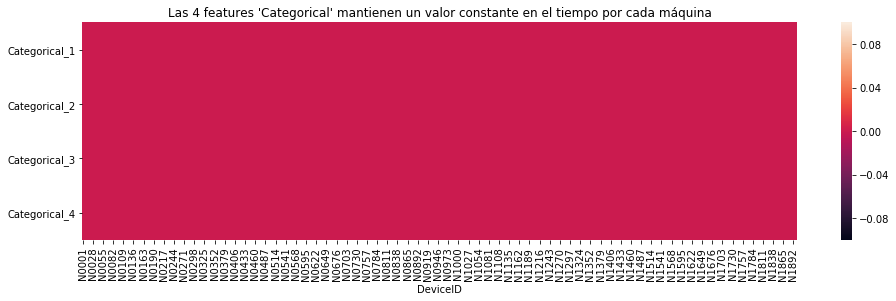

```python
# Visualización de un heatmap con los valores de las features 'Categorical_X' por cada 'DeviceID'
pt1 = pd.pivot_table(df, values=['Categorical_1', 'Categorical_2', 'Categorical_3', 'Categorical_4'],
                     columns='DeviceID', aggfunc=np.std)
plt.figure(figsize = (16,4))
plt.title('Las 4 features \'Categorical\' mantienen un valor constante en el tiempo por cada máquina')
sns.heatmap(pt1)
```

```python
df_cat = df[['Categorical_1', 'Categorical_2', 'Categorical_3', 'Categorical_4']].describe()
df_cat.round(1)
```

|  | Categorical_1 | Categorical_2 | Categorical_3 | Categorical_4 |
| --- | --- | --- | --- | --- |
| count | 2085102.0 | 2085102.0 | 2085102.0 | 2085102.0 |
| mean | 9.1 | 3403.9 | 315.2 | 9630.1 |
| std | 4.9 | 878.9 | 111.3 | 5500.0 |
| min | 2.0 | 800.0 | 50.0 | 600.0 |
| 25% | 5.0 | 2500.0 | 200.0 | 5600.0 |
| 50% | 8.0 | 3500.0 | 350.0 | 8404.0 |
| 75% | 12.0 | 4000.0 | 350.0 | 12400.0 |
| max | 37.0 | 10000.0 | 800.0 | 37406.0 |

```python
# Creación de 4 features categóricas a partir de las 'Categorical_X', definiendo entre 3 y 4 categorías en cada una de ellas
df['Categorical_1_Grouped'] = pd.qcut(df['Categorical_1'], 4, labels=['LL', 'L', 'H', 'HH'])
df['Categorical_2_Grouped'] = pd.qcut(df['Categorical_2'], 4, labels=['LL', 'L', 'H', 'HH'])
df['Categorical_3_Grouped'] = pd.qcut(df['Categorical_3'], 3, labels=['LL', 'L', 'H'])
df['Categorical_4_Grouped'] = pd.qcut(df['Categorical_4'], 4, labels=['LL', 'L', 'H', 'HH'])

df_cat = df[['Categorical_1_Grouped', 'Categorical_2_Grouped', 'Categorical_3_Grouped', 'Categorical_4_Grouped']].describe()
df_cat.round(1)
```

|  | Categorical_1_Grouped | Categorical_2_Grouped | Categorical_3_Grouped | Categorical_4_Grouped |
| --- | --- | --- | --- | --- |
| count | 2085102 | 2085102 | 2085102 | 2085102 |
| unique | 4 | 4 | 3 | 4 |
| top | L | L | L | H |
| freq | 631350 | 972828 | 1152900 | 524844 |

#### Problem_Type_X

```python
df_pbm = df[['Problem_Type_1', 'Problem_Type_2', 'Problem_Type_3', 'Problem_Type_4']].describe()
df_pbm.round(1)
```

|  | Problem_Type_1 | Problem_Type_2 | Problem_Type_3 | Problem_Type_4 |
| --- | --- | --- | --- | --- |
| count | 2085102.0 | 2085102.0 | 2085102.0 | 2085102.0 |
| mean | 0.1 | 27.0 | 0.0 | 0.1 |
| std | 0.8 | 55.5 | 0.0 | 5.5 |
| min | 0.0 | 0.0 | 0.0 | 0.0 |
| 25% | 0.0 | 0.0 | 0.0 | 0.0 |
| 50% | 0.0 | 2.0 | 0.0 | 0.0 |
| 75% | 0.0 | 34.0 | 0.0 | 0.0 |
| max | 80.0 | 5649.0 | 20.0 | 790.0 |

#### Error_Count_X

```python
df_err = df[['Error_Count_1', 'Error_Count_2', 'Error_Count_3', 'Error_Count_4',
            'Error_Count_5', 'Error_Count_6', 'Error_Count_7', 'Error_Count_8']].describe()
df_err.round(1)
```

|  | Error_Count_1 | Error_Count_2 | Error_Count_3 | Error_Count_4 | Error_Count_5 | Error_Count_6 | Error_Count_7 | Error_Count_8 |
| --- | --- | --- | --- | --- | --- | --- | --- | --- |
| count | 2085102.0 | 2085102.0 | 2085102.0 | 2085102.0 | 2085102.0 | 2085102.0 | 2085102.0 | 2085102.0 |
| mean | 0.0 | 0.0 | 0.0 | 0.0 | 0.0 | 0.0 | 0.0 | 0.0 |
| std | 0.1 | 0.0 | 0.0 | 0.0 | 0.1 | 0.0 | 0.0 | 0.0 |
| min | 0.0 | 0.0 | 0.0 | 0.0 | 0.0 | 0.0 | 0.0 | 0.0 |
| 25% | 0.0 | 0.0 | 0.0 | 0.0 | 0.0 | 0.0 | 0.0 | 0.0 |
| 50% | 0.0 | 0.0 | 0.0 | 0.0 | 0.0 | 0.0 | 0.0 | 0.0 |
| 75% | 0.0 | 0.0 | 0.0 | 0.0 | 0.0 | 0.0 | 0.0 | 0.0 |
| max | 1.0 | 1.0 | 1.0 | 1.0 | 2.0 | 1.0 | 1.0 | 1.0 |

```python
df['Error_Count_5'] = [1 if x > 1 else x for x in df['Error_Count_5']]
df[['Error_Count_5']].describe().round(1)
```

|  | Error_Count_5 |
| --- | --- |
| count | 2085102.0 |
| mean | 0.0 |
| std | 0.1 |
| min | 0.0 |
| 25% | 0.0 |
| 50% | 0.0 |
| 75% | 0.0 |
| max | 1.0 |

#### Fault_Code_Type_X

```python
df_flt = df[['Fault_Code_Type_1', 'Fault_Code_Type_2', 'Fault_Code_Type_3', 'Fault_Code_Type_4']].describe()
df_flt
```

|  | Fault_Code_Type_1 | Fault_Code_Type_2 | Fault_Code_Type_3 | Fault_Code_Type_4 |
| --- | --- | --- | --- | --- |
| count | 2085102 | 2085102 | 2085102 | 2085102 |
| unique | 33 | 16 | 57 | 22 |
| top | Unknown | Unknown | Unknown | Unknown |
| freq | 2034466 | 2019426 | 1998693 | 2045509 |

```python
# Transformación de las features 'Fault_Code_type_X' de texto a entero
df['Fault_Code_Type_1_Count'] = [0 if x == 'Unknown' else 1 for x in df['Fault_Code_Type_1']]
df['Fault_Code_Type_2_Count'] = [0 if x == 'Unknown' else 1 for x in df['Fault_Code_Type_2']]
df['Fault_Code_Type_3_Count'] = [0 if x == 'Unknown' else 1 for x in df['Fault_Code_Type_3']]
df['Fault_Code_Type_4_Count'] = [0 if x == 'Unknown' else 1 for x in df['Fault_Code_Type_4']]
```

#### Creación de ratios que relativicen la frecuencia de aparición de avisos, problemas, fallos y errores en función del uso dado a la máquina:

```python
# Ratios 'Problem_Type_X' / 'Usage_Count_X'
df['Problem_Type_1_Per_Usage_1'] = np.where(df['Usage_Count_1'] == 0, 0, df['Problem_Type_1'] / df['Usage_Count_1'])
df['Problem_Type_2_Per_Usage_1'] = np.where(df['Usage_Count_1'] == 0, 0, df['Problem_Type_2'] / df['Usage_Count_1'])
df['Problem_Type_3_Per_Usage_1'] = np.where(df['Usage_Count_1'] == 0, 0, df['Problem_Type_3'] / df['Usage_Count_1'])
df['Problem_Type_4_Per_Usage_1'] = np.where(df['Usage_Count_1'] == 0, 0, df['Problem_Type_4'] / df['Usage_Count_1'])
df['Problem_Type_1_Per_Usage_2'] = np.where(df['Usage_Count_2'] == 0, 0, df['Problem_Type_1'] / df['Usage_Count_2'])
df['Problem_Type_2_Per_Usage_2'] = np.where(df['Usage_Count_2'] == 0, 0, df['Problem_Type_2'] / df['Usage_Count_2'])
df['Problem_Type_3_Per_Usage_2'] = np.where(df['Usage_Count_2'] == 0, 0, df['Problem_Type_3'] / df['Usage_Count_2'])
df['Problem_Type_4_Per_Usage_2'] = np.where(df['Usage_Count_2'] == 0, 0, df['Problem_Type_4'] / df['Usage_Count_2'])

# Ratios 'Fault_Code_Type_X_Count' / 'Usage_Count_X'
df['Fault_Code_Type_1_Per_Usage_1'] = np.where(df['Usage_Count_1'] == 0, 0, df['Fault_Code_Type_1_Count'] / df['Usage_Count_1'])
df['Fault_Code_Type_2_Per_Usage_1'] = np.where(df['Usage_Count_1'] == 0, 0, df['Fault_Code_Type_2_Count'] / df['Usage_Count_1'])
df['Fault_Code_Type_3_Per_Usage_1'] = np.where(df['Usage_Count_1'] == 0, 0, df['Fault_Code_Type_3_Count'] / df['Usage_Count_1'])
df['Fault_Code_Type_4_Per_Usage_1'] = np.where(df['Usage_Count_1'] == 0, 0, df['Fault_Code_Type_4_Count'] / df['Usage_Count_1'])
df['Fault_Code_Type_1_Per_Usage_2'] = np.where(df['Usage_Count_2'] == 0, 0, df['Fault_Code_Type_1_Count'] / df['Usage_Count_2'])
df['Fault_Code_Type_2_Per_Usage_2'] = np.where(df['Usage_Count_2'] == 0, 0, df['Fault_Code_Type_2_Count'] / df['Usage_Count_2'])
df['Fault_Code_Type_3_Per_Usage_2'] = np.where(df['Usage_Count_2'] == 0, 0, df['Fault_Code_Type_3_Count'] / df['Usage_Count_2'])
df['Fault_Code_Type_4_Per_Usage_2'] = np.where(df['Usage_Count_2'] == 0, 0, df['Fault_Code_Type_4_Count'] / df['Usage_Count_2'])

# Ratios 'Warning_Type_X' / 'Usage_Count_X'
df['Warning_Type_1_Per_Usage_1'] = np.where(df['Usage_Count_1'] == 0, 0, df['Warning_Type_1'] / df['Usage_Count_1'])
df['Warning_Type_2_Per_Usage_1'] = np.where(df['Usage_Count_1'] == 0, 0, df['Warning_Type_2'] / df['Usage_Count_1'])
df['Warning_Type_1_Per_Usage_2'] = np.where(df['Usage_Count_2'] == 0, 0, df['Warning_Type_1'] / df['Usage_Count_2'])
df['Warning_Type_2_Per_Usage_2'] = np.where(df['Usage_Count_2'] == 0, 0, df['Warning_Type_2'] / df['Usage_Count_2'])
```

#### Procesado de los ratios: discretización por categorías (_Grouped) y escalado entre [0, 1] con normalización min-max

```python
# Transformación de las features recientemente creadas a categóricas
ratio_features = [feature for feature in df.columns if 'Per_Usage' in feature]

for feature in ratio_features:
    df[feature + '_Grouped'] = ['>1' if x > 1 else '>0' if x > 0 else 'Zero' for x in df[feature]]

# Creación de un dataframe con todas las features categóricas
features_grouped = [feature for feature in df.columns if '_Grouped' in feature]
features_grouped.extend(['Error_Count_1', 'Error_Count_2', 'Error_Count_3', 'Error_Count_4',
                         'Error_Count_5', 'Error_Count_6', 'Error_Count_7', 'Error_Count_8'])
df_grp = df[features_grouped]
df_grp.head()
```

|  | Categorical_1_Grouped | Categorical_2_Grouped | Categorical_3_Grouped | Categorical_4_Grouped | Problem_Type_1_Per_Usage_1_Grouped | Problem_Type_2_Per_Usage_1_Grouped | Problem_Type_3_Per_Usage_1_Grouped | Problem_Type_4_Per_Usage_1_Grouped | Problem_Type_1_Per_Usage_2_Grouped | Problem_Type_2_Per_Usage_2_Grouped | ... | Warning_Type_1_Per_Usage_2_Grouped | Warning_Type_2_Per_Usage_2_Grouped | Error_Count_1 | Error_Count_2 | Error_Count_3 | Error_Count_4 | Error_Count_5 | Error_Count_6 | Error_Count_7 | Error_Count_8 |
| --- | --- | --- | --- | --- | --- | --- | --- | --- | --- | --- | --- | --- | --- | --- | --- | --- | --- | --- | --- | --- | --- |
| 0 | L | LL | LL | L | Zero | Zero | Zero | Zero | Zero | Zero | ... | Zero | Zero | 0 | 0 | 0 | 0 | 0 | 0 | 0 | 0 |
| 1 | L | LL | LL | L | Zero | Zero | Zero | Zero | Zero | Zero | ... | Zero | Zero | 0 | 0 | 0 | 0 | 0 | 0 | 0 | 0 |
| 2 | L | LL | LL | L | Zero | Zero | Zero | Zero | Zero | Zero | ... | Zero | Zero | 0 | 0 | 0 | 0 | 0 | 0 | 0 | 0 |
| 3 | L | LL | LL | L | Zero | Zero | Zero | Zero | Zero | Zero | ... | Zero | Zero | 0 | 0 | 0 | 0 | 0 | 0 | 0 | 0 |
| 4 | L | LL | LL | L | Zero | Zero | Zero | Zero | Zero | Zero | ... | Zero | Zero | 0 | 0 | 0 | 0 | 0 | 0 | 0 | 0 |

5 rows × 32 columns

```python
# One-Hot Encoder
df_grp_ohe = pd.DataFrame()

for feature in df_grp.columns:
    temp = pd.get_dummies(df_grp[feature], prefix=feature)
    df_grp_ohe[temp.columns] = temp

df_grp_ohe.head()
```

|  | Categorical_1_Grouped_LL | Categorical_1_Grouped_L | Categorical_1_Grouped_H | Categorical_1_Grouped_HH | Categorical_2_Grouped_LL | Categorical_2_Grouped_L | Categorical_2_Grouped_H | Categorical_2_Grouped_HH | Categorical_3_Grouped_LL | Categorical_3_Grouped_L | ... | Error_Count_4_0 | Error_Count_4_1 | Error_Count_5_0 | Error_Count_5_1 | Error_Count_6_0 | Error_Count_6_1 | Error_Count_7_0 | Error_Count_7_1 | Error_Count_8_0 | Error_Count_8_1 |
| --- | --- | --- | --- | --- | --- | --- | --- | --- | --- | --- | --- | --- | --- | --- | --- | --- | --- | --- | --- | --- | --- |
| 0 | 0 | 1 | 0 | 0 | 1 | 0 | 0 | 0 | 1 | 0 | ... | 1 | 0 | 1 | 0 | 1 | 0 | 1 | 0 | 1 | 0 |
| 1 | 0 | 1 | 0 | 0 | 1 | 0 | 0 | 0 | 1 | 0 | ... | 1 | 0 | 1 | 0 | 1 | 0 | 1 | 0 | 1 | 0 |
| 2 | 0 | 1 | 0 | 0 | 1 | 0 | 0 | 0 | 1 | 0 | ... | 1 | 0 | 1 | 0 | 1 | 0 | 1 | 0 | 1 | 0 |
| 3 | 0 | 1 | 0 | 0 | 1 | 0 | 0 | 0 | 1 | 0 | ... | 1 | 0 | 1 | 0 | 1 | 0 | 1 | 0 | 1 | 0 |
| 4 | 0 | 1 | 0 | 0 | 1 | 0 | 0 | 0 | 1 | 0 | ... | 1 | 0 | 1 | 0 | 1 | 0 | 1 | 0 | 1 | 0 |

5 rows × 83 columns

```python
# Eliminación de las features '_Grouped'
print('Número de features previo:', df.shape[1])
df = df.drop([feature for feature in df.columns if '_Grouped' in feature], axis=1)
print('Número de features tras la eliminación:', df.shape[1])

# Inclusión de las nuevas features OHE al dataset
df = pd.concat([df, df_grp_ohe], axis=1)
print('Número de features tras la inclusión:', df.shape[1])
```

```
Número de features previo: 225
Número de features tras la eliminación: 201
Número de features tras la inclusión: 284
```

```python
# Escalado mediante normalización Min-Max
from sklearn.preprocessing import MinMaxScaler

scaler = MinMaxScaler()

for feature in ratio_features:
    df[feature] = scaler.fit_transform(np.array(df[feature]).reshape(-1, 1))

df[[feature for feature in ratio_features]].describe()
```

|  | Problem_Type_1_Per_Usage_1 | Problem_Type_2_Per_Usage_1 | Problem_Type_3_Per_Usage_1 | Problem_Type_4_Per_Usage_1 | Problem_Type_1_Per_Usage_2 | Problem_Type_2_Per_Usage_2 | Problem_Type_3_Per_Usage_2 | Problem_Type_4_Per_Usage_2 | Fault_Code_Type_1_Per_Usage_1 | Fault_Code_Type_2_Per_Usage_1 | Fault_Code_Type_3_Per_Usage_1 | Fault_Code_Type_4_Per_Usage_1 | Fault_Code_Type_1_Per_Usage_2 | Fault_Code_Type_2_Per_Usage_2 | Fault_Code_Type_3_Per_Usage_2 | Fault_Code_Type_4_Per_Usage_2 | Warning_Type_1_Per_Usage_1 | Warning_Type_2_Per_Usage_1 | Warning_Type_1_Per_Usage_2 | Warning_Type_2_Per_Usage_2 |
| --- | --- | --- | --- | --- | --- | --- | --- | --- | --- | --- | --- | --- | --- | --- | --- | --- | --- | --- | --- | --- |
| count | 2.085102e+06 | 2.085102e+06 | 2.085102e+06 | 2.085102e+06 | 2.085102e+06 | 2.085102e+06 | 2.085102e+06 | 2.085102e+06 | 2.085102e+06 | 2.085102e+06 | 2.085102e+06 | 2.085102e+06 | 2.085102e+06 | 2.085102e+06 | 2.085102e+06 | 2.085102e+06 | 2.085102e+06 | 2.085102e+06 | 2.085102e+06 | 2.085102e+06 |
| mean | 3.035300e-04 | 1.830884e-04 | 3.870221e-06 | 2.598609e-04 | 6.619626e-05 | 6.294360e-05 | 1.601723e-05 | 8.053779e-06 | 1.971076e-04 | 1.858047e-04 | 2.131538e-04 | 7.190571e-05 | 2.430517e-04 | 3.331298e-04 | 4.300615e-04 | 1.537016e-04 | 2.262220e-05 | 2.325075e-05 | 1.658009e-05 | 3.268712e-05 |
| std | 8.064972e-03 | 8.766719e-04 | 1.070702e-03 | 1.430753e-02 | 2.017468e-03 | 2.109286e-03 | 2.058868e-03 | 1.328000e-03 | 8.440072e-03 | 7.413326e-03 | 7.779539e-03 | 4.327456e-03 | 9.722748e-03 | 1.292298e-02 | 1.531022e-02 | 8.892225e-03 | 1.557848e-03 | 2.111216e-03 | 1.330025e-03 | 2.645723e-03 |
| min | 0.000000e+00 | 0.000000e+00 | 0.000000e+00 | 0.000000e+00 | 0.000000e+00 | 0.000000e+00 | 0.000000e+00 | 0.000000e+00 | 0.000000e+00 | 0.000000e+00 | 0.000000e+00 | 0.000000e+00 | 0.000000e+00 | 0.000000e+00 | 0.000000e+00 | 0.000000e+00 | 0.000000e+00 | 0.000000e+00 | 0.000000e+00 | 0.000000e+00 |
| 25% | 0.000000e+00 | 0.000000e+00 | 0.000000e+00 | 0.000000e+00 | 0.000000e+00 | 0.000000e+00 | 0.000000e+00 | 0.000000e+00 | 0.000000e+00 | 0.000000e+00 | 0.000000e+00 | 0.000000e+00 | 0.000000e+00 | 0.000000e+00 | 0.000000e+00 | 0.000000e+00 | 0.000000e+00 | 0.000000e+00 | 0.000000e+00 | 0.000000e+00 |
| 50% | 0.000000e+00 | 7.797879e-05 | 0.000000e+00 | 0.000000e+00 | 0.000000e+00 | 0.000000e+00 | 0.000000e+00 | 0.000000e+00 | 0.000000e+00 | 0.000000e+00 | 0.000000e+00 | 0.000000e+00 | 0.000000e+00 | 0.000000e+00 | 0.000000e+00 | 0.000000e+00 | 0.000000e+00 | 0.000000e+00 | 0.000000e+00 | 0.000000e+00 |
| 75% | 0.000000e+00 | 2.780868e-04 | 0.000000e+00 | 0.000000e+00 | 0.000000e+00 | 4.715306e-05 | 0.000000e+00 | 0.000000e+00 | 0.000000e+00 | 0.000000e+00 | 0.000000e+00 | 0.000000e+00 | 0.000000e+00 | 0.000000e+00 | 0.000000e+00 | 0.000000e+00 | 0.000000e+00 | 0.000000e+00 | 0.000000e+00 | 0.000000e+00 |
| max | 1.000000e+00 | 1.000000e+00 | 1.000000e+00 | 1.000000e+00 | 1.000000e+00 | 1.000000e+00 | 1.000000e+00 | 1.000000e+00 | 1.000000e+00 | 1.000000e+00 | 1.000000e+00 | 1.000000e+00 | 1.000000e+00 | 1.000000e+00 | 1.000000e+00 | 1.000000e+00 | 1.000000e+00 | 1.000000e+00 | 1.000000e+00 | 1.000000e+00 |

#### 4 AutoEncoders para reducir el número de features (en lugar de PCA)

```python
# Creación de las features que pasarán por los 4 autoencoders: un autoencoder para cada grupo de warnings y modo de uso
df_ae_t1_u1 = pd.DataFrame()
df_ae_t1_u2 = pd.DataFrame()
df_ae_t2_u1 = pd.DataFrame()
df_ae_t2_u2 = pd.DataFrame()

for feature in warning_type1_features:
    df_ae_t1_u1[feature + '_Per_Usage_1'] = np.where(df['Usage_Count_1'] == 0, 0, df[feature] / df['Usage_Count_1'])
    df_ae_t1_u2[feature + '_Per_Usage_2'] = np.where(df['Usage_Count_2'] == 0, 0, df[feature] / df['Usage_Count_2'])

for feature in warning_type2_features:
    df_ae_t2_u1[feature + '_Per_Usage_1'] = np.where(df['Usage_Count_1'] == 0, 0, df[feature] / df['Usage_Count_1'])
    df_ae_t2_u2[feature + '_Per_Usage_2'] = np.where(df['Usage_Count_2'] == 0, 0, df[feature] / df['Usage_Count_2'])
```

```python
# Normalización Min-Max
scaler = MinMaxScaler()
for column in df_ae_t1_u1.columns:
    df_ae_t1_u1[column] = scaler.fit_transform(np.array(df_ae_t1_u1[column]).reshape(-1, 1))

for column in df_ae_t1_u2.columns:
    df_ae_t1_u2[column] = scaler.fit_transform(np.array(df_ae_t1_u2[column]).reshape(-1, 1))

for column in df_ae_t2_u1.columns:
    df_ae_t2_u1[column] = scaler.fit_transform(np.array(df_ae_t2_u1[column]).reshape(-1, 1))

for column in df_ae_t2_u2.columns:
    df_ae_t2_u2[column] = scaler.fit_transform(np.array(df_ae_t2_u2[column]).reshape(-1, 1))
```

```python
from keras.models import Model
from keras.layers import Input, Dense

# Definimos la semilla aleatoria para fijar los resultados obtenidos
seed = 2019
np.random.seed(seed)
AE_FEATURES_NUM = 5

# AutoEncoder 1: Modelado del autoencoder mediante la API funcional
entrada = Input(shape=(df_ae_t1_u1.shape[1],))
codificado = Dense(AE_FEATURES_NUM, activation='relu', name='capa_intermedia')(entrada)
decodificado = Dense(df_ae_t1_u1.shape[1], activation='relu')(codificado)
autoencoder = Model(entrada, decodificado)

# AutoEncoder 1: Modelado del encoder para obtener los datos compactos
encoder1 = Model(autoencoder.input, autoencoder.get_layer('capa_intermedia').output)

# AutoEncoder 1: Construcción y entrenamiento del autoencoder
autoencoder.compile(optimizer='nadam', loss='mse', metrics=['accuracy'])
autoencoder.fit(df_ae_t1_u1, df_ae_t1_u1, epochs=3)
```

```
WARNING:tensorflow:From C:\Users\ayfdcp\AppData\Local\Continuum\anaconda3\lib\site-packages\tensorflow\python\framework\op_def_library.py:263: colocate_with (from tensorflow.python.framework.ops) is deprecated and will be removed in a future version.
Instructions for updating:
Colocations handled automatically by placer.
WARNING:tensorflow:From C:\Users\ayfdcp\AppData\Local\Continuum\anaconda3\lib\site-packages\tensorflow\python\ops\math_ops.py:3066: to_int32 (from tensorflow.python.ops.math_ops) is deprecated and will be removed in a future version.
Instructions for updating:
Use tf.cast instead.
```

```
<keras.callbacks.History at 0x2945fa0dc18>
```

```python
# AutoEncoder 2: Modelado del autoencoder mediante la API funcional
entrada = Input(shape=(df_ae_t1_u2.shape[1],))
codificado = Dense(AE_FEATURES_NUM, activation='relu', name='capa_intermedia')(entrada)
decodificado = Dense(df_ae_t1_u2.shape[1], activation='relu')(codificado)
autoencoder = Model(entrada, decodificado)

# AutoEncoder 2: Modelado del encoder para obtener los datos compactos
encoder2 = Model(autoencoder.input, autoencoder.get_layer('capa_intermedia').output)

# AutoEncoder 2: Construcción y entrenamiento del autoencoder
autoencoder.compile(optimizer='nadam', loss='mse', metrics=['accuracy'])
autoencoder.fit(df_ae_t1_u2, df_ae_t1_u2, epochs=3)
```

```
<keras.callbacks.History at 0x2945fb5ad30>
```

```python
# AutoEncoder 3: Modelado del autoencoder mediante la API funcional
entrada = Input(shape=(df_ae_t2_u1.shape[1],))
codificado = Dense(AE_FEATURES_NUM, activation='relu', name='capa_intermedia')(entrada)
decodificado = Dense(df_ae_t2_u1.shape[1], activation='relu')(codificado)
autoencoder = Model(entrada, decodificado)

# AutoEncoder 3: Modelado del encoder para obtener los datos compactos
encoder3 = Model(autoencoder.input, autoencoder.get_layer('capa_intermedia').output)

# AutoEncoder 3: Construcción y entrenamiento del autoencoder
autoencoder.compile(optimizer='nadam', loss='mse', metrics=['accuracy'])
autoencoder.fit(df_ae_t2_u1, df_ae_t2_u1, epochs=3)
```

```
<keras.callbacks.History at 0x29469591320>
```

```python
# AutoEncoder 4: Modelado del autoencoder mediante la API funcional
entrada = Input(shape=(df_ae_t2_u2.shape[1],))
codificado = Dense(AE_FEATURES_NUM, activation='relu', name='capa_intermedia')(entrada)
decodificado = Dense(df_ae_t2_u2.shape[1], activation='relu')(codificado)
autoencoder = Model(entrada, decodificado)

# AutoEncoder 4: Modelado del encoder para obtener los datos compactos
encoder4 = Model(autoencoder.input, autoencoder.get_layer('capa_intermedia').output)

# AutoEncoder 4: Construcción y entrenamiento del autoencoder
autoencoder.compile(optimizer='nadam', loss='mse', metrics=['accuracy'])
autoencoder.fit(df_ae_t2_u2, df_ae_t2_u2, epochs=3)
```

```
<keras.callbacks.History at 0x2946a111358>
```

```python
# Eliminación de las features 'Warning_X.X'
df = df.drop([feature for feature in warning_features], axis=1)
print('Número de features tras la eliminación:', df.shape[1])

# Obtención de las 20 features comprimidas por el encoder
df_ae_t1_u1 = encoder1.predict(df_ae_t1_u1)
df_ae_t1_u1 = pd.DataFrame(df_ae_t1_u1, columns=['AE_T1U1_Warning_' + str(i + 1) for i in range(AE_FEATURES_NUM)])

df_ae_t1_u2 = encoder2.predict(df_ae_t1_u2)
df_ae_t1_u2 = pd.DataFrame(df_ae_t1_u2, columns=['AE_T1U2_Warning_' + str(i + 1) for i in range(AE_FEATURES_NUM)])

df_ae_t2_u1 = encoder3.predict(df_ae_t2_u1)
df_ae_t2_u1 = pd.DataFrame(df_ae_t2_u1, columns=['AE_T2U1_Warning_' + str(i + 1) for i in range(AE_FEATURES_NUM)])

df_ae_t2_u2 = encoder4.predict(df_ae_t2_u2)
df_ae_t2_u2 = pd.DataFrame(df_ae_t2_u2, columns=['AE_T2U2_Warning_' + str(i + 1) for i in range(AE_FEATURES_NUM)])

# Normalización Min-Max de los resultados compactos
scaler = MinMaxScaler()
for column in df_ae_t1_u1.columns:
    df_ae_t1_u1[column] = scaler.fit_transform(np.array(df_ae_t1_u1[column]).reshape(-1, 1))

for column in df_ae_t1_u2.columns:
    df_ae_t1_u2[column] = scaler.fit_transform(np.array(df_ae_t1_u2[column]).reshape(-1, 1))

for column in df_ae_t2_u1.columns:
    df_ae_t2_u1[column] = scaler.fit_transform(np.array(df_ae_t2_u1[column]).reshape(-1, 1))

for column in df_ae_t2_u2.columns:
    df_ae_t2_u2[column] = scaler.fit_transform(np.array(df_ae_t2_u2[column]).reshape(-1, 1))

# Inclusión de las nuevas features al dataset
df = pd.concat([df, df_ae_t1_u1, df_ae_t1_u2, df_ae_t2_u1, df_ae_t2_u2], axis=1)
print('Número de features tras la inclusión:', df.shape[1])
```

```
Número de features tras la eliminación: 137
Número de features tras la inclusión: 157
```

## Guardado de datos

```python
df.to_pickle('./sampledata2.pkl')
```